“— title:”Homework 8" author: “Alexander Van Roijen” date: “March 1, 2019” output: pdf_document —

```r
require("sandwich")
require("msm")
cellData = read.csv('cells.csv')
teethData = read.csv('Teeth.csv')
```

```r
#first we figure out how to do the poisson regression, and then recall that the coefficients, if not exponentiated, is the difference in log mean per unit difference of our parameter. However, when exponentiated, it is the ratio between mean number of the response per unit difference of our variable.
poisRes= glm(count1 ~ dose +sex +age +count0, family="poisson", data=cellData)
psum = summary(poisRes)
print(psum)
```

```
##
## Call:
## glm(formula = count1 ~ dose + sex + age + count0, family = "poisson",
##     data = cellData)
##
## Deviance Residuals:
##     Min       1Q   Median       3Q      Max
## -26.924   -5.282   -1.411    3.957   29.779
##
## Coefficients:
##               Estimate Std. Error z value Pr(>|z|)
## (Intercept)  4.4301424  0.0466576  94.950   <2e-16 ***
## dose         0.0277232  0.0003444  80.506   <2e-16 ***
## sex          0.1919804  0.0213115   9.008   <2e-16 ***
## age         -0.0228122  0.0006803 -33.533   <2e-16 ***
## count0       0.0052013  0.0001438  36.180   <2e-16 ***
## ---
## Signif. codes:  0 '***' 0.001 '**' 0.01 '*' 0.05 '.' 0.1 ' ' 1
##
## (Dispersion parameter for poisson family taken to be 1)
##
##     Null deviance: 17055.9  on 39  degrees of freedom
## Residual deviance:  4018.9  on 35  degrees of freedom
## AIC: 4278.9
##
## Number of Fisher Scoring iterations: 5
```

1. The above holds the coefficient table and the summary for the poisson regression on the cell data with adjustment for the required factors

```r
print(exp(psum$coefficients[2,1]))
```

```
## [1] 1.028111
```

b/c) Accordingly, dose, which is significant, when we exponentiate the coefficient represents the ratio of the mean post cell counts per unit difference in dose. Thus the ratio of the mean post cell counts, holding everything else constant, is 1.028 per unit increase in dosage.

```r
v <- vcovHC(poisRes)
robust.se <- sqrt(diag(v))
round(cbind(psum$coef,robust.se),4)
```

```
##             Estimate Std. Error  z value Pr(>|z|) robust.se
## (Intercept)   4.4301     0.0467  94.9501        0    0.5724
## dose          0.0277     0.0003  80.5063        0    0.0028
## sex           0.1920     0.0213   9.0083        0    0.4806
## age          -0.0228     0.0007 -33.5333        0    0.0157
## count0        0.0052     0.0001  36.1797        0    0.0022
```

4. Now looking at the the robust standard errors, we can see there are quite significant departures, showing that we should likely use robust standard errors. Also note that they are quite larger than our previously calculated standard errors. Now lets examine the assumptions

```r
print(length(cellData$id))
```

```
## [1] 40
```

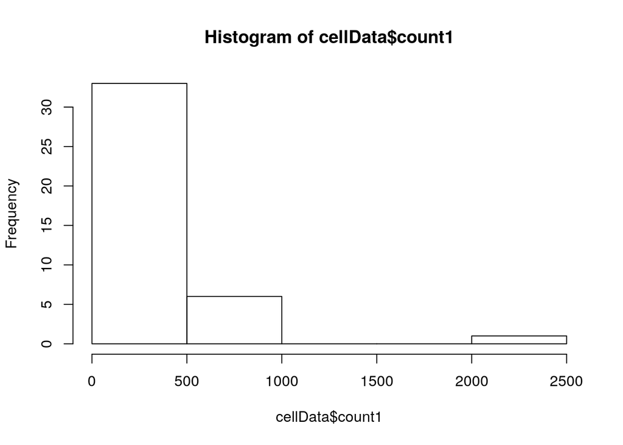

```r
hist(cellData$count1)
```

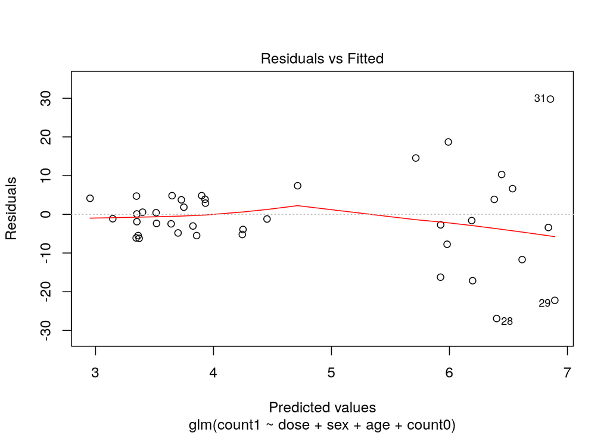

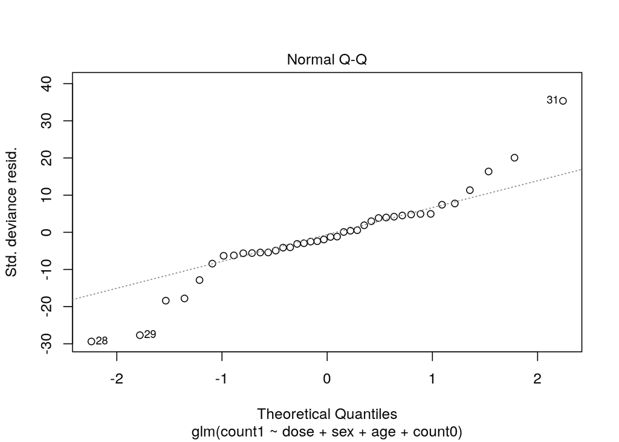

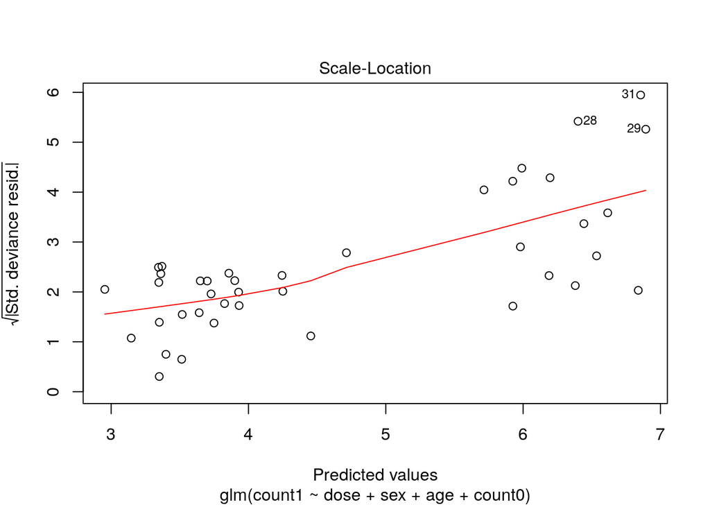

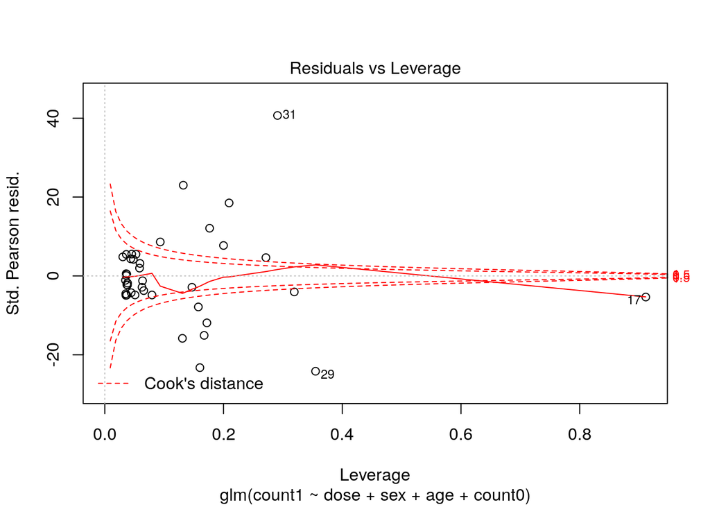

```r
plot(poisRes)
```

```r
print(c(mean(cellData$count1),var(cellData$count1)))
```

```
## [1]    251.05 156884.56
```

```r
#variance equal to mean assumption? slide 12
```

e/f) We can see that our residuals show a non-constant variance, which agrees with the usage of robust SEs. Comparing to our results from homework 7, our other predictors became significant along with dose. However, the much lower than robust standard errors likely caused part of this. The reason for this may be to a lack of good fit of poisson regression to this data. First, we note a rather small sample size of 40, along with the fact that the $Var(Y) \ne \mu$

```r
poisRes= glm(count1 ~ factor(dose) +sex +age +count0, family="poisson", data=cellData)
psum = summary(poisRes)
print(psum)
```

```
##
## Call:
## glm(formula = count1 ~ factor(dose) + sex + age + count0, family = "poisson",
##     data = cellData)
##
## Deviance Residuals:
##     Min       1Q   Median       3Q      Max
## -26.845   -4.809   -1.107    3.594   29.722
##
## Coefficients:
##                  Estimate Std. Error z value Pr(>|z|)
## (Intercept)      4.518128   0.054452  82.974   <2e-16 ***
## factor(dose)10   0.100033   0.059844   1.672   0.0946 .
## factor(dose)100  2.678908   0.045693  58.628   <2e-16 ***
## sex              0.193511   0.021322   9.076   <2e-16 ***
## age             -0.022820   0.000681 -33.507   <2e-16 ***
## count0           0.005406   0.000161  33.572   <2e-16 ***
## ---
## Signif. codes:  0 '***' 0.001 '**' 0.01 '*' 0.05 '.' 0.1 ' ' 1
##
## (Dispersion parameter for poisson family taken to be 1)
##
##     Null deviance: 17055.9  on 39  degrees of freedom
## Residual deviance:  4010.2  on 34  degrees of freedom
## AIC: 4272.2
##
## Number of Fisher Scoring iterations: 5
```

```r
print(exp(psum$coefficients[1:3,1]))
```

```
##     (Intercept)  factor(dose)10 factor(dose)100
##       91.663807        1.105208       14.569178
```

```r
copyTeeth = teethData
copyTeeth$newExtr = as.integer(as.logical(teethData$EXTR))
teethResB = (summary(glm(newExtr~PDALL+AGE+GENDER, data=copyTeeth, family=binomial)))
print(teethResB)
```

```
##
## Call:
## glm(formula = newExtr ~ PDALL + AGE + GENDER, family = binomial,
##     data = copyTeeth)
##
## Deviance Residuals:
##     Min       1Q   Median       3Q      Max
## -1.6678  -0.5769  -0.4611  -0.3570   2.5168
##
## Coefficients:
##             Estimate Std. Error z value Pr(>|z|)
## (Intercept) -8.36031    1.03959  -8.042 8.84e-16 ***
## PDALL        1.45168    0.16710   8.687  < 2e-16 ***
## AGE          0.03035    0.01460   2.079   0.0376 *
## GENDERM     -0.33090    0.20589  -1.607   0.1080
## ---
## Signif. codes:  0 '***' 0.001 '**' 0.01 '*' 0.05 '.' 0.1 ' ' 1
##
## (Dispersion parameter for binomial family taken to be 1)
##
##     Null deviance: 724.76  on 795  degrees of freedom
## Residual deviance: 636.30  on 792  degrees of freedom
##   (1 observation deleted due to missingness)
## AIC: 644.3
##
## Number of Fisher Scoring iterations: 5
```

```r
teethResP = (summary(glm(newExtr~PDALL+AGE+GENDER, data=copyTeeth, family=poisson)))
print(teethResP)
```

```
##
## Call:
## glm(formula = newExtr ~ PDALL + AGE + GENDER, family = poisson,
##     data = copyTeeth)
##
## Deviance Residuals:
##     Min       1Q   Median       3Q      Max
## -1.3132  -0.5486  -0.4700  -0.3984   1.9304
##
## Coefficients:
##             Estimate Std. Error z value Pr(>|z|)
## (Intercept) -6.11233    0.77177  -7.920 2.38e-15 ***
## PDALL        0.91241    0.10350   8.816  < 2e-16 ***
## AGE          0.01990    0.01235   1.612    0.107
## GENDERM     -0.23356    0.17464  -1.337    0.181
## ---
## Signif. codes:  0 '***' 0.001 '**' 0.01 '*' 0.05 '.' 0.1 ' ' 1
##
## (Dispersion parameter for poisson family taken to be 1)
##
##     Null deviance: 479.07  on 795  degrees of freedom
## Residual deviance: 415.91  on 792  degrees of freedom
##   (1 observation deleted due to missingness)
## AIC: 693.91
##
## Number of Fisher Scoring iterations: 6
```

```r
pdallL = (teethResB$coefficients[2,1])
pdExp = exp(pdallL)
print(pdExp)
```

```
## [1] 4.270297
```

```r
ageCoef = (teethResB$coefficients[3,1])
expACoef = exp(ageCoef)
print(expACoef)
```

```
## [1] 1.030816
```

```r
poisData = (teethResP$coefficients[1:2,1])
pdpExp = exp(poisData)
print(pdpExp)
```

```
## (Intercept)       PDALL
##  0.00221539  2.49030950
```

a)Looking at the results of our logistic regression model, we see that PDALL and AGE are significant.

c)Looking at the results of the poisson regression, we can see that only PDALL is significant in this model.

4. Finally for the poisson model, the exponentiated coefficient of 2.5 for PDALL indicates an increase in the rate ratio by a factor of that 2.5 per unit increase in the PDALL term assuming all other terms held constant. Note the baseline ratio of 0.0022. I do not bother interpreting the other parameters as they are not signficant.
5. Overall, the models give similar results. They both indicate a positive relationship between the odds of a patient having a tooth extracted and the PDALL term. However, they disagree on the significance of the age relationship, but agree on its sign.

## Problem 4, bonus

Lets tackle this proof through simulation.

```r
minXs = rep(10,25)
maxXs = rep(40,25)
allData = c(minXs,maxXs)
meanX = mean(allData)
print(meanX)
```

```
## [1] 25
```

```r
print(sum((allData-meanX)**2))
```

```
## [1] 11250
```

Now, we know that our assumptions of linearity, constant variance, and indepndence are met.

We further understand that the formula for $SE(\hat{\beta}) = \frac{\hat{\sigma}}{\sqrt{\sum^{n=50}_{i=1}(X_i-\bar{X})^2}}$

Knowing this, along with out assumptions, we can see that our $\hat{\sigma}$ and $n$ are constant. Thus, the only thing that can change in our calculation is the value of $\sqrt{\sum^{n=50}_{i=1}(X_i-\bar{X})^2}$. Further, given the range $10 \le X_i \le 40$, we must ensure our values satisfy this requirement.

We can see inuitively, that we must maximize that square root of a sum to maximize the denominator and ultimatley minimize the SE.

Thus, lets examine what happens to the sum of squared differences (ignoring the square root as it is meaningless to our goal) when we shift some values around.

```r
newData = allData
newData[50] = 39
newMean = mean(newData)
print(newMean)
```

```
## [1] 24.98
```

```r
print(sum((newData-newMean)**2))
```

```
## [1] 11220.98
```

We can see that lowering one of our Xs at 40 resulted in a net decrease in sum of squared differences. This trend holds due to the negative derivative found when taking the first derivative of our $SE$ with respect to our $X_i$.

The same holds for increasing our Xs at 10, due to the symmetric property of this relationship.

If we shift all data down, our results should reflect, inuitively, another overal decrease.

```r
minXs = rep(10,25)
maxXs = rep(39,25)
allData = c(minXs,maxXs)
meanX = mean(allData)
print(meanX)
```

```
## [1] 24.5
```

```r
print(sum((allData-meanX)**2))
```

```
## [1] 10512.5
```

looking at all results, we can see that negative relationship we refferred to.

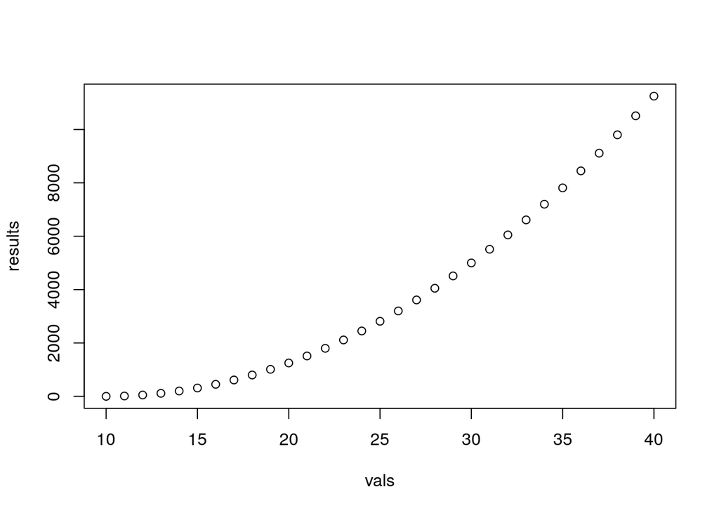

```r
startMax = 40
results = numeric()
vals = numeric()
counter = 1
while(startMax>=10)
{
  minXs = rep(10,25)
  maxXs = rep(startMax,25)
  allData = c(minXs,maxXs)
  meanX = mean(allData)
  results[counter] = sum((allData-meanX)**2)
  vals[counter] = startMax
  counter = counter +1
  startMax= startMax-1
}
plot(x=vals,y=results)
```

This would normally continue on indefinetly if there were no bounds to either end of our range.